# Data_Analysis_Replication

Marcelle

4/3/2022

## Introduction

### Goal

The goal of this paper is to test the effectiveness of the proposed behavioral paradigm, retrieval+extinction on male, Long-Evans Rats with previous moderate alcohol exposure. The effectiveness of the retrieval+extinction paradigm, where an extinction session is conducted during the retrieval induced memory reconsolidation window, is tested for return of alcohol-seeking behavior under reinstatement and spontaneous recovery conditions, or Long-Term Testing.

### Homecage Induction

The data set `induction` describes the average ethanol consumption of the male Long-Evans rats during home-cage drinking. The mean consumption increases over sessions. The graph is divided into the two groups, treatment group retrieval+extinction and control group.

### Descriptive data

This data set was used to show the introduction and subsequent acquisition of voluntary drinking behavior in the rodent model. The means show a positive trend as sessions progress.

[figure not shown]

### Conditioning

Rats were conditioned to associate a light visual cue to the presentation of a sipper containing alcohol before moving on to extinction. During this phase, it is imperative rats acquire the association before moving forward and exposed to either treatment or control extinction.

Approach behavior is only reported during conditioning phases preCS CS1 CS2 (sipper is absent which is needed for contact data)

Sipper data is reported for trial phase CS3 and CS4

#Analysis All groups successfully acquired alcohol-seeking behavior as evidenced by a similar positive trend in acquisition in approach and contact behavior over sessions.

[figure not shown]

### Long-Term Testing

To test for retrieval-extinction’s effectiveness on this rodent model, reinstatement conditions, or cue presentation, were replicated to check for return of ‘extinguished’ behavior. The “Long-Term test” data set compares approach and contact behavior during Long-term testing (trial 4), where sponatneous recovery conditions were replicated after 24 hours after last extinction session as baseline, to approach and contact behavior at resintatement (trial 1). The data set also compares baseline, extinction session 14 (final extinction session to trial 1) to reinstatement (trial 1).

Contact only occurs in the presence of sipper which is presented conditioning session trial pahse CS3 abd CS4.

```r
#importing data set for contact data cs3 and cs4
r <- "https://raw.githubusercontent.com/MarcelleO/data-analysis-replication/main/data/contact_by_window-E14LTMTRT.csv"
dr <- read_csv(r, col_names = TRUE)
head(dr)
```

```
## # A tibble: 6 x 8
##   window trial session subject   con group cohort   rater
##   <chr>  <dbl> <chr>   <chr>   <dbl> <chr> <chr>    <chr>
## 1 CS3        1 LTMT    aa          4 NORET winter15 KT
## 2 CS3        2 LTMT    aa          2 NORET winter15 KT
## 3 CS3        3 LTMT    aa          0 NORET winter15 KT
## 4 CS3        4 LTMT    aa          0 NORET winter15 KT
## 5 CS4        1 LTMT    aa          4 NORET winter15 KT
## 6 CS4        2 LTMT    aa          4 NORET winter15 KT
```

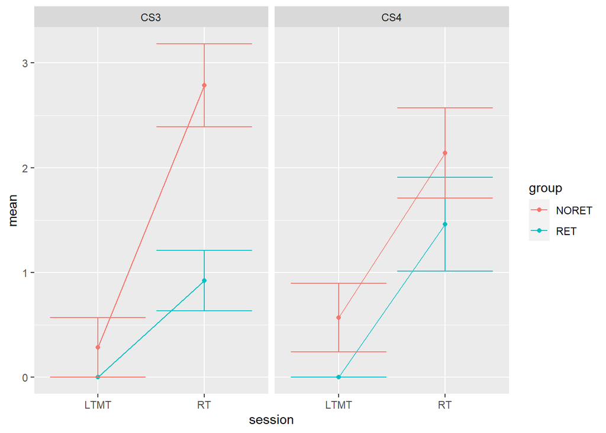

```r
#make sure eveything is interpreted as factor
dr$window <- as.factor(dr$window)
dr$session <- as.factor(dr$session)
dr$group <- as.factor(dr$group)
dr$trial <- as.factor(dr$trial)

#Data analysis utilizes long-term memory test trial 4 as baseline and reinstatement trial 1 as test
#filter out LTMT and RT sessions from the data set

LTMT_con <- dr %>%
  select(session, trial, con, window, group)%>%
filter((session=="LTMT" & trial ==4)| (session=="RT" & trial ==1))

#create new columns with mean sd and se

LTMT_con2<- LTMT_con%>%
  group_by(group, session, window)%>%
 mutate(mean= mean(con),
         sd=sd(con),
         n=n(),
         se=sd(con)/sqrt(n()),
         )

#plot

p4 <- ggplot(aes(x=session, y=mean, group= group, colour=group), data = LTMT_con2) +
  geom_line(aes(group = group, color=group)) + geom_point() + facet_wrap(~window)+ geom_errorbar(aes(ymin=mean-se, ymax=mean+se))

p4
```

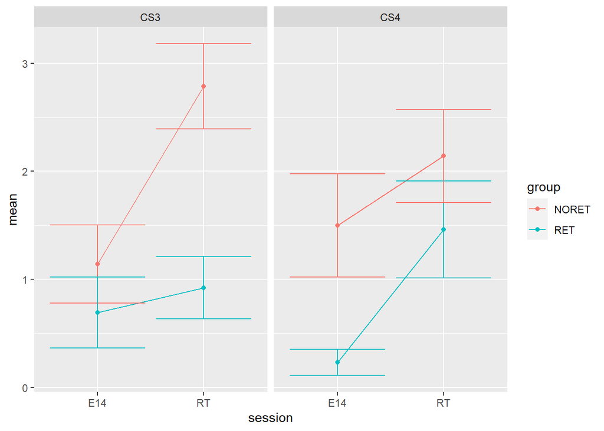

```r
#E14 compared to RT
#filter E14 trial 1 and RT trial 1

E14_con <- dr%>%
  select(group, session, trial, con, window)%>%
  filter((session == "E14" & trial == 1) | (session == "RT" & trial ==1))

#create new columns with mean sd and se
E14_con2<- E14_con%>%
  group_by(group,session, window)%>%
  mutate(mean= mean(con),
         sd=sd(con),
         n=n(),
         se=sd(con)/sqrt(n()))
#plot

p5 <- ggplot(aes(session, mean, group= group, colour=group), data = E14_con2) +
  geom_line(aes(group = group, color=group)) + geom_point() + facet_wrap(~window) + geom_errorbar(aes(ymin=mean-se, ymax=mean+se))

p5
```

```r
#import data set for approach data preCS, CS1, CS2

j <- "https://raw.githubusercontent.com/MarcelleO/data-analysis-replication/main/data/approach_by_window-E14LTMTRT.csv"
dj <- read_csv(j, col_names = TRUE)
```

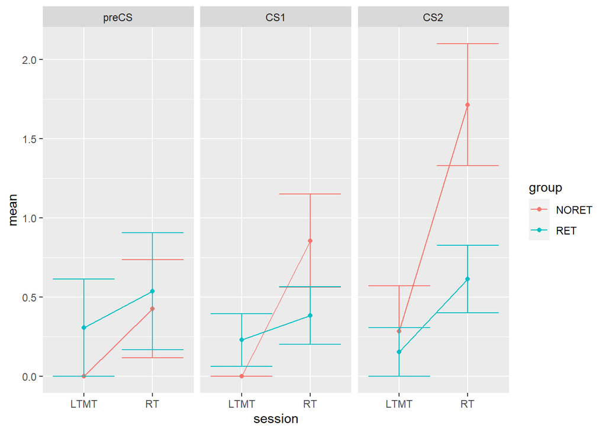

```r
#make sure everything is interpreted as factor
dj$window <- factor(dj$window, levels= c("preCS", "CS1", "CS2"))
dj$session <- as.factor(dj$session)
dj$group <- as.factor(dj$group)
dj$trial <- as.factor(dj$trial)

#Data analysis utilizes long-term memory test trial 4 as baseline and reinstatement trial 1 as test
#filter out LTMT and RT sessions from the data set
LTMT_app <- dj%>%
  select(group, session, trial, app, window)%>%
  filter((session == "LTMT" & trial == 4) | (session == "RT" & trial ==1))%>%
  filter(window %in% c("preCS", "CS1", "CS2"))

#create new columns with mean sd and se

LTMT_app2<- LTMT_app%>%
  group_by(group, session, window)%>%
 mutate(mean= mean(app),
         sd=sd(app),
         sd=sd(app),
         n=n(),
         se=sd(app)/sqrt(n()),
         )
#plot

p6 <- ggplot(aes(session, mean, group= group, colour=group), data = LTMT_app2) +
  geom_line(aes(group = group, color=group)) + geom_point() + facet_wrap(~window) + geom_errorbar(aes(ymin=mean-se, ymax=mean+se))

p6
```

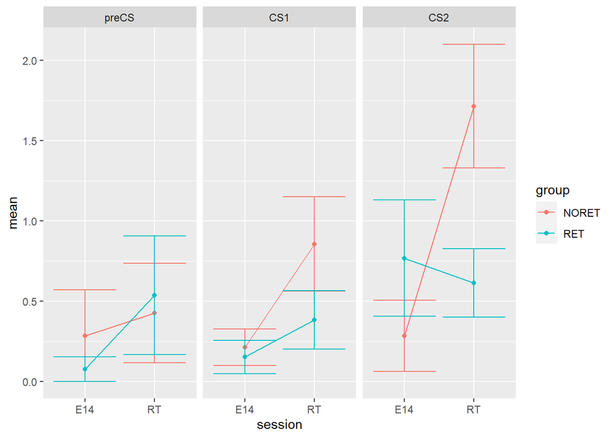

```r
#E14 compared to RT
#filter E14 trial 1 and RT trial 1 window preCS CS1 CS2

E14_app <- dj%>%
  select(group, session, trial, app, window)%>%
  filter((session == "E14" & trial == 1) | (session == "RT" & trial ==1))%>%
  filter(window %in% c("preCS", "CS1", "CS2"))

#create new columns with mean sd and se

E14_app2<- E14_app%>%
  group_by(group, session, window)%>%
 mutate(mean= mean(app),
         sd=sd(app),
         sd=sd(app),
         n=n(),
         se=sd(app)/sqrt(n()),
         )

#plot

p7 <- ggplot(aes(session, mean, group= group, colour=group), data = E14_app2) +
  geom_line(aes(group = group, color=group)) + geom_point() + facet_wrap(~window) + geom_errorbar(aes(ymin=mean-se, ymax=mean+se))

p7
```

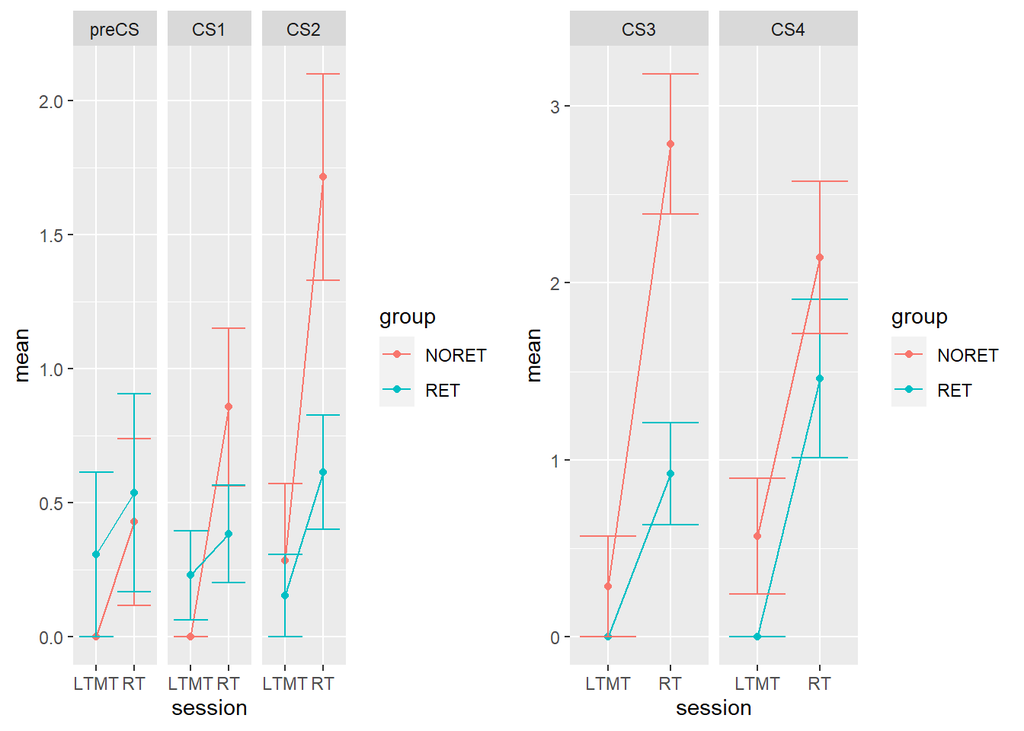

```r
#join the plots
plot_64 <- plot_grid(p6, p4)

plot_64
```

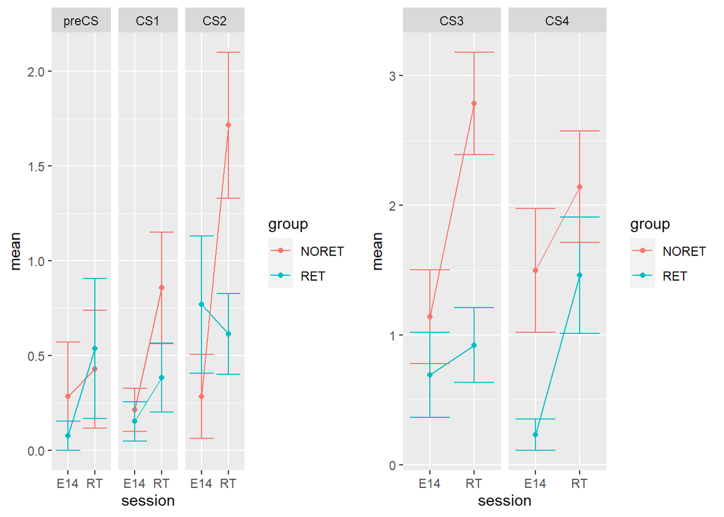

```r
plot_75 <- plot_grid(p7, p5)

plot_75
```

### Analysis

Two p values were used to determine significance. p < 0.05 and p < 0.07

Original published results: ### Conclusion The t-tests showed a significant return of behavior for the control group No-retrieval during phases CS2 and CS3 during reinstatement. This data supports the original hypothesis, retrieval-extinction is an effective paradigm to reduce return of alcohol-seeking behavior in rodent models exposed to moderate alcohol.

```r
# run one sided t-tests for RT  trial 1 mean and LTM trial 1 mean for groups retrieval+extinction vs Extinction
#run one sided t-test for RT  trial 1 mean and E14 trial 1 mean for groups retrieval+extinction vs Extinction
#Welch's t-tests were run for each phase

#pull mean behavior for each phase to compare RT and LTMT session

LT_pre_x <-  LTMT_app%>%
   filter(window== "preCS", group== "NORET", session=="LTMT")%>%
  select(app)
LT_pre_y <-  LTMT_app%>%
   filter(window== "preCS", group== "NORET", session=="RT")%>%
  select(app)

LT_pre_x2 <-  LTMT_app%>%
   filter(window== "preCS", group== "RET", session=="LTMT")%>%
  select(app)

LT_pre_y2 <-  LTMT_app%>%
   filter(window== "preCS", group== "RET", session=="RT")%>%
  select(app)

LT_CS1_x <-LTMT_app%>%
   filter(window== "CS1", group== "NORET", session=="LTMT")%>%
  select(app)

LT_CS1_y <-LTMT_app%>%
   filter(window== "CS1", group== "NORET", session=="RT")%>%
  select(app)

LT_CS1_x2 <-LTMT_app%>%
   filter(window== "CS1", group== "RET", session=="LTMT")%>%
  select(app)

LT_CS1_y2 <-LTMT_app%>%
   filter(window== "CS1", group== "RET", session=="RT")%>%
  select(app)

LT_CS2_x <-LTMT_app%>%
   filter(window== "CS2", group== "NORET", session=="LTMT")%>%
  select(app)

LT_CS2_y <-LTMT_app%>%
   filter(window== "CS2", group== "NORET", session=="RT")%>%
  select(app)

LT_CS2_x2 <-LTMT_app%>%
   filter(window== "CS2", group== "RET", session=="LTMT")%>%
  select(app)

LT_CS2_y2 <-LTMT_app%>%
   filter(window== "CS2", group== "RET", session=="RT")%>%
  select(app)

LT_CS3_x <- LTMT_con%>%
  filter(window== "CS3", group== "NORET", session=="LTMT")%>%
  select(con)
LT_CS3_y <- LTMT_con%>%
 filter(window== "CS3", group== "NORET", session=="RT")%>%
  select(con)
LT_CS3_x2<- LTMT_con%>%
  filter(window== "CS3", group== "RET", session=="LTMT")%>%
  select(con)
LT_CS3_y2 <- LTMT_con%>%
 filter(window== "CS3", group== "RET", session=="RT")%>%
  select(con)

LT_CS4_x <- LTMT_con%>%
filter(window== "CS4", group== "NORET", session=="LTMT")%>%
  select(con)
LT_CS4_y<- LTMT_con%>%
  filter(window== "CS4", group== "NORET", session=="RT")%>%
  select(con)
LT_CS4_x2<- LTMT_con%>%
filter(window== "CS4", group== "RET", session=="LTMT")%>%
  select(con)
LT_CS4_y2<- LTMT_con%>%
  filter(window== "CS4", group== "RET", session=="RT")%>%
  select(con)



E_pre_x<- E14_app%>%
  filter(window== "preCS", group== "NORET", session=="E14")%>%
  select(app)
E_pre_y<- E14_app%>%
  filter(window== "preCS", group== "NORET", session=="RT")%>%
  select(app)
E_pre_x2 <- E14_app%>%
  filter(window== "preCS", group== "RET", session=="E14")%>%
  select(app)
E_pre_y2 <- E14_app%>%
  filter(window== "preCS", group== "RET", session=="RT")%>%
  select(app)
E_CS1_x<-E14_app%>%
  filter(window== "CS1", group== "NORET", session=="E14")%>%
  select(app)
E_CS1_y <-E14_app%>%
  filter(window== "CS1", group== "NORET", session=="RT")%>%
  select(app)
E_CS1_x2<-E14_app%>%
  filter(window== "CS1", group== "RET", session=="E14")%>%
  select(app)
E_CS1_y2 <-E14_app%>%
  filter(window== "CS1", group== "RET", session=="RT")%>%
  select(app)
E_CS2_x <-E14_app%>%
  filter(window== "CS2", group== "NORET", session=="E14")%>%
  select(app)
E_CS2_y <-E14_app%>%
  filter(window== "CS2", group== "NORET", session=="RT")%>%
  select(app)
E_CS2_x2 <-E14_app%>%
  filter(window== "CS2", group== "RET", session=="E14")%>%
  select(app)
E_CS2_y2 <-E14_app%>%
  filter(window== "CS2", group== "RET", session=="RT")%>%
  select(app)
E_CS3_x <- E14_con %>%
  filter(window== "CS3", group== "NORET", session=="E14")%>%
  select(con)
E_CS3_y <- E14_con %>%
   filter(window== "CS3", group== "NORET", session=="RT")%>%
  select(con)
E_CS3_x2 <- E14_con %>%
   filter(window== "CS3", group== "RET", session=="E14")%>%
  select(con)
E_CS3_y2 <- E14_con %>%
 filter(window== "CS3", group== "RET", session=="RT")%>%
  select(con)
E_CS4_x <-E14_con %>%
   filter(window== "CS4", group== "NORET", session=="E14")%>%
  select(con)
E_CS4_y <-E14_con %>%
   filter(window== "CS4", group== "NORET", session=="RT")%>%
  select(con)
E_CS4_x2 <-E14_con %>%
   filter(window== "CS4", group== "RET", session=="E14")%>%
  select(con)
E_CS4_y2 <-E14_con %>%
   filter(window== "CS4", group== "RET", session=="RT")%>%
  select(con)

#run welch's t-test for each phase (window) (20 total)
#LTMT trial 4 compared to RT trial 1 contact means AKA  comparing ret+extinction vs Extinction
LTMT_preN <- t.test(LT_pre_x , LT_pre_y)
  LTMT_preN$p.value
```

```
## [1] 0.1893812
```

```r
LTMT_preR <- t.test(LT_pre_x2 , LT_pre_y2)
  LTMT_preR$p.value
```

```
## [1] 0.635443
```

```r
LTMT_CS1N <- t.test(LT_CS1_x , LT_CS1_y)
  LTMT_CS1N$p.value
```

```
## [1] 0.01200869
```

```r
LTMT_CS1R <- t.test(LT_CS1_x2 , LT_CS1_y)
  LTMT_CS1R$p.value
```

```
## [1] 0.07803972
```

```r
LTMT_CS2N <- t.test(LT_CS2_x , LT_CS2_y)
  LTMT_CS2N$p.value
```

```
## [1] 0.006444061
```

```r
LTMT_CS2R <- t.test(LT_CS2_x2, LT_CS2_y2)
  LTMT_CS2R$p.value
```

```
## [1] 0.09299473
```

```r
LTMT_CS3N <- t.test(LT_CS3_x, LT_CS3_y)
  LTMT_CS3N$p.value
```

```
## [1] 3.101378e-05
```

```r
LTMT_CS3R <- t.test(LT_CS3_x2, LT_CS3_y2)
  LTMT_CS3R$p.value
```

```
## [1] 0.007532147
```

```r
LTMT_CS4N <- t.test(LT_CS4_x, LT_CS4_y)
  LTMT_CS4N$p.value
```

```
## [1] 0.007663234
```

```r
LTMT_CS4R <- t.test(LT_CS4_x2, LT_CS4_y2)
  LTMT_CS4R$p.value
```

```
## [1] 0.006746985
```

```r
E14_preE <- t.test( E_pre_x, E_pre_y)
  E14_preE$p.value
```

```
## [1] 0.7372144
```

```r
E14_preR <- t.test( E_pre_x2, E_pre_y2)
  E14_preR$p.value
```

```
## [1] 0.2423336
```

```r
E14_CS1E <-  t.test( E_CS1_x, E_CS1_y)
  E14_CS1E$p.value
```

```
## [1] 0.05736785
```

```r
E14_CS1R <-  t.test( E_CS1_x2, E_CS1_y2)
  E14_CS1R$p.value
```

```
## [1] 0.2816238
```

```r
E14_CS2E <-t.test( E_CS2_x, E_CS2_y)
  E14_CS2E$p.value
```

```
## [1] 0.004109109
```

```r
E14_CS2R <-t.test( E_CS2_x2, E_CS2_y2)
  E14_CS2R$p.value
```

```
## [1] 0.7174375
```

```r
E14_CS3E <-t.test(  E_CS3_x, E_CS3_y)
  E14_CS3E$p.value
```

```
## [1] 0.004972631
```

```r
E14_CS3R <-t.test(  E_CS3_x2, E_CS3_y2)
  E14_CS3R$p.value
```

```
## [1] 0.6017764
```

```r
E14_CS4E <- t.test(  E_CS4_x, E_CS4_y)
  E14_CS4E$p.value
```

```
## [1] 0.3266248
```

```r
E14_CS4R <- t.test(  E_CS4_x2, E_CS4_y2)
  E14_CS4R$p.value
```

```
## [1] 0.01908297
```

[figure not shown]

### Discussion

The data used to replicate the analysis was not available on line or published online. As a result, the data was acquired after reaching out to the author for the data sets. The first hurdle was trying to determine what data sets were used for which analyses because they were not labeled clearly. In addition the data sets were not clear sometimes as to the groups or behavioral procedure the data is describing (trial 1 but no mention if this was conditioning data or extinction data).

The data was sent to me by the first author, and was already cleaned and R friendly. The majority of the time dedicated to replicating the data was figuring out how to manipulate the data frames to begin the analyses.

### References

Cofresi et al (2017) Alcohol Clin Exp Res 41(3):608-617